# EDA-Capstone

```python
import pandas as pd
import seaborn as sns
import matplotlib.pyplot as plt
import numpy as np

pd.set_option('display.max_columns', None)

import warnings
warnings.filterwarnings("ignore")

plt.rcParams['font.sans-serif'] = "Arial"
plt.rcParams['font.family'] = "sans-serif"
background_color = '#fbfbfb'
color1 = '#C32D4B'
color2 = '#18846c'
color3 = '#6698FF'
```

```python
data = pd.read_csv('jds-usecase-2.csv')
df = data.copy()
df.head(2)
```

|  | no | kode_provinsi | nama_provinsi | bps_kode_kabupaten_kota | bps_nama_kabupaten_kota | bps_kode_kecamatan | bps_nama_kecamatan | bps_kode_desa_kelurahan | bps_nama_desa_kelurahan | kemendagri_kode_kecamatan | kemendagri_nama_kecamatan | kemendagri_kode_desa_kelurahan | kemendagri_nama_desa_kelurahan | iks_2020 | ike_2020 | ikl_2020 | nilai_idm_2020 | status_idm_2020 | ekologi_airdesa | ekologi_dampak_cemar | ekonomi_transumum | ekonomi_jalan_desa | ekonomi_kualitas_jalan | ekonomi_status_bumdesa | ekonomi_status_bumdesa_bersama | ekonomi_bumdes_bid_pariwisata | sosial_bidang_modal_sosial_suku | sosial_bidang_modal_sosial_bahasa | sosial_bidang_modal_sosial_agama_mayoritas | … |
| --- | --- | --- | --- | --- | --- | --- | --- | --- | --- | --- | --- | --- | --- | --- | --- | --- | --- | --- | --- | --- | --- | --- | --- | --- | --- | --- | --- | --- | --- | --- |
| 0 | 1 | 32 | JAWA BARAT | 3201 | KABUPATEN BOGOR | 3201190 | GUNUNG PUTRI | 3201190006 | WANAHERANG | 32.01.02 | GUNUNG PUTRI | 32.01.02.2001 | WANAHERANG | 0.9486 | 0.85 | 0.3333 | 0.7106 | MAJU | 1 | 1 | 1 | 1 | 1 | 1 | 0 | 0 | 5 | 5 | 1 | … |
| 1 | 2 | 32 | JAWA BARAT | 3201 | KABUPATEN BOGOR | 3201190 | GUNUNG PUTRI | 3201190010 | BOJONG KULUR | 32.01.02 | GUNUNG PUTRI | 32.01.02.2002 | BOJONG KULUR | 0.9600 | 1.00 | 0.9333 | 0.9644 | MANDIRI | 1 | 1 | 1 | 1 | 1 | 1 | 0 | 0 | 2 | 3 | 1 | … |

```python
df = df.drop(['no','kode_provinsi', 'bps_kode_kabupaten_kota', 'bps_kode_kecamatan', 'bps_kode_desa_kelurahan',
              'kemendagri_kode_kecamatan', 'kemendagri_nama_kecamatan', 'kemendagri_kode_desa_kelurahan',
              'kemendagri_nama_desa_kelurahan'], axis=1)

df.head(2)
```

|  | nama_provinsi | bps_nama_kabupaten_kota | bps_nama_kecamatan | bps_nama_desa_kelurahan | iks_2020 | ike_2020 | ikl_2020 | nilai_idm_2020 | status_idm_2020 | ekologi_airdesa | ekologi_dampak_cemar | ekonomi_transumum | ekonomi_jalan_desa | ekonomi_kualitas_jalan | ekonomi_status_bumdesa | ekonomi_status_bumdesa_bersama | ekonomi_bumdes_bid_pariwisata | sosial_bidang_modal_sosial_suku | sosial_bidang_modal_sosial_bahasa | sosial_bidang_modal_sosial_agama_mayoritas | sosial_bidang_pemukiman_sinyal | ekonomi_hotel | ekonomi_jarak_hotel | ekonomi_menit_hotel | ekonomi_penghasilan | ekonomi_produk_unggul | ekonomi_umikrokecil_industri_rt | ekonomi_umikrokecil_pariwisata | ekonomi_umikrokecil_perikanan | … |
| --- | --- | --- | --- | --- | --- | --- | --- | --- | --- | --- | --- | --- | --- | --- | --- | --- | --- | --- | --- | --- | --- | --- | --- | --- | --- | --- | --- | --- | --- | --- |
| 0 | JAWA BARAT | KABUPATEN BOGOR | GUNUNG PUTRI | WANAHERANG | 0.9486 | 0.85 | 0.3333 | 0.7106 | MAJU | 1 | 1 | 1 | 1 | 1 | 1 | 0 | 0 | 5 | 5 | 1 | 1 | 1 | 1000 | 10 | 2 | 0 | 0 | 0 | 0 | … |
| 1 | JAWA BARAT | KABUPATEN BOGOR | GUNUNG PUTRI | BOJONG KULUR | 0.9600 | 1.00 | 0.9333 | 0.9644 | MANDIRI | 1 | 1 | 1 | 1 | 1 | 1 | 0 | 0 | 2 | 3 | 1 | 1 | 1 | 300 | 3 | 3 | 0 | 8 | 0 | 0 | … |

```python
df.isnull().sum(axis=0)/len(df)*100
```

```
nama_provinsi                                 0.0
bps_nama_kabupaten_kota                       0.0
bps_nama_kecamatan                            0.0
bps_nama_desa_kelurahan                       0.0
iks_2020                                      0.0
ike_2020                                      0.0
ikl_2020                                      0.0
nilai_idm_2020                                0.0
status_idm_2020                               0.0
ekologi_airdesa                               0.0
ekologi_dampak_cemar                          0.0
ekonomi_transumum                             0.0
ekonomi_jalan_desa                            0.0
ekonomi_kualitas_jalan                        0.0
ekonomi_status_bumdesa                        0.0
ekonomi_status_bumdesa_bersama                0.0
ekonomi_bumdes_bid_pariwisata                 0.0
sosial_bidang_modal_sosial_suku               0.0
sosial_bidang_modal_sosial_bahasa             0.0
sosial_bidang_modal_sosial_agama_mayoritas    0.0
sosial_bidang_pemukiman_sinyal                0.0
ekonomi_hotel                                 0.0
ekonomi_jarak_hotel                           0.0
ekonomi_menit_hotel                           0.0
ekonomi_penghasilan                           0.0
ekonomi_produk_unggul                         0.0
ekonomi_umikrokecil_industri_rt               0.0
ekonomi_umikrokecil_pariwisata                0.0
ekonomi_umikrokecil_perikanan                 0.0
ekonomi_umikrokecil_pertanian                 0.0
ekonomi_umikrokecil_peternakan                0.0
ekonomi_umikrokecil_lainnya                   0.0
ekonomi_pariwisata_wisata_desa                0.0
ekonomi_pariwisata_agrowisata                 0.0
ekonomi_pariwisata_wisata_alam                0.0
ekonomi_pariwisata_transportasi               0.0
identitas_demografi_desa_total_penduduk       0.0
dtype: float64
```

```python
df.duplicated().sum()
```

```
0
```

```python
df.columns
```

```
Index(['nama_provinsi', 'bps_nama_kabupaten_kota', 'bps_nama_kecamatan',
       'bps_nama_desa_kelurahan', 'iks_2020', 'ike_2020', 'ikl_2020',
       'nilai_idm_2020', 'status_idm_2020', 'ekologi_airdesa',
       'ekologi_dampak_cemar', 'ekonomi_transumum', 'ekonomi_jalan_desa',
       'ekonomi_kualitas_jalan', 'ekonomi_status_bumdesa',
       'ekonomi_status_bumdesa_bersama', 'ekonomi_bumdes_bid_pariwisata',
       'sosial_bidang_modal_sosial_suku', 'sosial_bidang_modal_sosial_bahasa',
       'sosial_bidang_modal_sosial_agama_mayoritas',
       'sosial_bidang_pemukiman_sinyal', 'ekonomi_hotel',
       'ekonomi_jarak_hotel', 'ekonomi_menit_hotel', 'ekonomi_penghasilan',
       'ekonomi_produk_unggul', 'ekonomi_umikrokecil_industri_rt',
       'ekonomi_umikrokecil_pariwisata', 'ekonomi_umikrokecil_perikanan',
       'ekonomi_umikrokecil_pertanian', 'ekonomi_umikrokecil_peternakan',
       'ekonomi_umikrokecil_lainnya', 'ekonomi_pariwisata_wisata_desa',
       'ekonomi_pariwisata_agrowisata', 'ekonomi_pariwisata_wisata_alam',
       'ekonomi_pariwisata_transportasi',
       'identitas_demografi_desa_total_penduduk'],
      dtype='object')
```

```python
df['ekologi_airdesa'] = df['ekologi_airdesa'].replace([1, 2, 3], ['Ya, Sepanjang Tahun', 'Ya, Kecuali Saat Tertentu',
                                                                  'Tidak Tersedia Sumber Air'])
df['ekologi_dampak_cemar'] = df['ekologi_dampak_cemar'].replace([0, 1, 2, 3], ['Tidak Mempengaruhi Kesehatan',
                                                                               'Gangguan Kesehatan Ringan',
                                                                               'Menimbulkan Penyakit', 'Menimbulkan Kematian'])
df['ekonomi_transumum'] = df['ekonomi_transumum'].replace([1, 2, 3], ['Ada, Trayek Tetap', 'Ada, Tanpa Trayek Tetap',
                                                                      'Tidak Ada Angkutan Umum'])
df['ekonomi_jalan_desa'] = df['ekonomi_jalan_desa'].replace([0, 1, 2, 3], ['Tidak ada', 'Sepanjang tahun',
                                                                           'Sepanjang tahun kecuali saat tertentu',
                                                                           'Tidak dapat dilalui sepanjang tahun'])
df['ekonomi_kualitas_jalan'] = df['ekonomi_kualitas_jalan'].replace([1, 2, 3], ['Baik', 'Rusak sedang', 'Rusak parah'])
df['ekonomi_status_bumdesa'] = df['ekonomi_status_bumdesa'].replace([0, 1], ['Tidak aktif', 'Aktif'])
df['ekonomi_status_bumdesa_bersama'] = df['ekonomi_status_bumdesa_bersama'].replace([0, 1], ['Tidak aktif', 'Aktif'])
df['ekonomi_bumdes_bid_pariwisata'] = df['ekonomi_bumdes_bid_pariwisata'].replace([0, 1], ['Tidak ada', 'Ada'])
df['sosial_bidang_modal_sosial_agama_mayoritas'] = df['sosial_bidang_modal_sosial_agama_mayoritas'].replace([0, 1], ['Tidak ada', 'Ada'])
df['sosial_bidang_pemukiman_sinyal'] = df['sosial_bidang_pemukiman_sinyal'].replace([0, 1, 2], ['Tidak ada sinyal', 'Sinyal Kuat',
                                                                                               'Sinyal Lemah'])
df['ekonomi_hotel'] = df['ekonomi_hotel'].replace([0, 1], ['Tidak ada', 'Ada'])
df['ekonomi_penghasilan'] = df['ekonomi_penghasilan'].replace([1, 2, 3, 4, 5], ['Pertanian', 'Industri',
                                                                                'Perdagangan, Trans, dan Jasa', 'Pariwisata',
                                                                                'Lainnya'])
df['ekonomi_produk_unggul'] = df['ekonomi_produk_unggul'].replace([0, 1], ['Tidak ada', 'Ada'])
df['ekonomi_pariwisata_wisata_desa'] = df['ekonomi_pariwisata_wisata_desa'].replace([0, 1], ['Tidak ada', 'Ada'])
df['ekonomi_pariwisata_agrowisata'] = df['ekonomi_pariwisata_agrowisata'].replace([0, 1], ['Tidak ada', 'Ada'])
df['ekonomi_pariwisata_wisata_alam'] = df['ekonomi_pariwisata_wisata_alam'].replace([0, 1], ['Tidak ada', 'Ada'])
df['ekonomi_pariwisata_transportasi'] = df['ekonomi_pariwisata_transportasi'].replace([0, 1], ['Tidak ada', 'Ada'])

df.head(2)
```

|  | nama_provinsi | bps_nama_kabupaten_kota | bps_nama_kecamatan | bps_nama_desa_kelurahan | iks_2020 | ike_2020 | ikl_2020 | nilai_idm_2020 | status_idm_2020 | ekologi_airdesa | ekologi_dampak_cemar | ekonomi_transumum | ekonomi_jalan_desa | ekonomi_kualitas_jalan | ekonomi_status_bumdesa | ekonomi_status_bumdesa_bersama | ekonomi_bumdes_bid_pariwisata | sosial_bidang_modal_sosial_suku | sosial_bidang_modal_sosial_bahasa | sosial_bidang_modal_sosial_agama_mayoritas | sosial_bidang_pemukiman_sinyal | ekonomi_hotel | ekonomi_jarak_hotel | ekonomi_menit_hotel | ekonomi_penghasilan | ekonomi_produk_unggul | ekonomi_umikrokecil_industri_rt | ekonomi_umikrokecil_pariwisata | ekonomi_umikrokecil_perikanan | … |
| --- | --- | --- | --- | --- | --- | --- | --- | --- | --- | --- | --- | --- | --- | --- | --- | --- | --- | --- | --- | --- | --- | --- | --- | --- | --- | --- | --- | --- | --- | --- |
| 0 | JAWA BARAT | KABUPATEN BOGOR | GUNUNG PUTRI | WANAHERANG | 0.9486 | 0.85 | 0.3333 | 0.7106 | MAJU | Ya, Sepanjang Tahun | Gangguan Kesehatan Ringan | Ada, Trayek Tetap | Sepanjang tahun | Baik | Aktif | Tidak aktif | Tidak ada | 5 | 5 | Ada | Sinyal Kuat | Ada | 1000 | 10 | Industri | Tidak ada | 0 | 0 | 0 | … |
| 1 | JAWA BARAT | KABUPATEN BOGOR | GUNUNG PUTRI | BOJONG KULUR | 0.9600 | 1.00 | 0.9333 | 0.9644 | MANDIRI | Ya, Sepanjang Tahun | Gangguan Kesehatan Ringan | Ada, Trayek Tetap | Sepanjang tahun | Baik | Aktif | Tidak aktif | Tidak ada | 2 | 3 | Ada | Sinyal Kuat | Ada | 300 | 3 | Perdagangan, Trans, dan Jasa | Tidak ada | 8 | 0 | 0 | … |

```python
df[df.bps_nama_kabupaten_kota == 'KABUPATEN BOGOR']
```

|  | nama_provinsi | bps_nama_kabupaten_kota | bps_nama_kecamatan | bps_nama_desa_kelurahan | iks_2020 | ike_2020 | ikl_2020 | nilai_idm_2020 | status_idm_2020 | ekologi_airdesa | ekologi_dampak_cemar | ekonomi_transumum | ekonomi_jalan_desa | ekonomi_kualitas_jalan | ekonomi_status_bumdesa | ekonomi_status_bumdesa_bersama | ekonomi_bumdes_bid_pariwisata | sosial_bidang_modal_sosial_suku | sosial_bidang_modal_sosial_bahasa | sosial_bidang_modal_sosial_agama_mayoritas | sosial_bidang_pemukiman_sinyal | ekonomi_hotel | ekonomi_jarak_hotel | ekonomi_menit_hotel | ekonomi_penghasilan | ekonomi_produk_unggul | ekonomi_umikrokecil_industri_rt | ekonomi_umikrokecil_pariwisata | ekonomi_umikrokecil_perikanan | … |
| --- | --- | --- | --- | --- | --- | --- | --- | --- | --- | --- | --- | --- | --- | --- | --- | --- | --- | --- | --- | --- | --- | --- | --- | --- | --- | --- | --- | --- | --- | --- |
| 0 | JAWA BARAT | KABUPATEN BOGOR | GUNUNG PUTRI | WANAHERANG | 0.9486 | 0.8500 | 0.3333 | 0.7106 | MAJU | Ya, Sepanjang Tahun | Gangguan Kesehatan Ringan | Ada, Trayek Tetap | Sepanjang tahun | Baik | Aktif | Tidak aktif | Tidak ada | 5 | 5 | Ada | Sinyal Kuat | Ada | 1000 | 10 | Industri | Tidak ada | 0 | 0 | 0 | … |
| 1 | JAWA BARAT | KABUPATEN BOGOR | GUNUNG PUTRI | BOJONG KULUR | 0.9600 | 1.0000 | 0.9333 | 0.9644 | MANDIRI | Ya, Sepanjang Tahun | Gangguan Kesehatan Ringan | Ada, Trayek Tetap | Sepanjang tahun | Baik | Aktif | Tidak aktif | Tidak ada | 2 | 3 | Ada | Sinyal Kuat | Ada | 300 | 3 | Perdagangan, Trans, dan Jasa | Tidak ada | 8 | 0 | 0 | … |
| 2 | JAWA BARAT | KABUPATEN BOGOR | GUNUNG PUTRI | CIANGSANA | 0.9943 | 0.9667 | 0.8667 | 0.9425 | MANDIRI | Ya, Sepanjang Tahun | Gangguan Kesehatan Ringan | Ada, Trayek Tetap | Sepanjang tahun | Baik | Aktif | Tidak aktif | Tidak ada | 8 | 8 | Ada | Sinyal Kuat | Tidak ada | 500 | 30 | Perdagangan, Trans, dan Jasa | Ada | 20 | 2 | 50 | … |
| 3 | JAWA BARAT | KABUPATEN BOGOR | GUNUNG PUTRI | GUNUNG PUTRI | 0.8914 | 0.8167 | 0.3333 | 0.6805 | BERKEMBANG | Ya, Kecuali Saat Tertentu | Gangguan Kesehatan Ringan | Ada, Trayek Tetap | Sepanjang tahun | Baik | Aktif | Tidak aktif | Tidak ada | 5 | 4 | Ada | Sinyal Kuat | Tidak ada | 0 | 0 | Perdagangan, Trans, dan Jasa | Tidak ada | 120 | 2 | 0 | … |
| 4 | JAWA BARAT | KABUPATEN BOGOR | GUNUNG PUTRI | BOJONG NANGKA | 0.9600 | 0.9333 | 0.7333 | 0.8756 | MANDIRI | Ya, Kecuali Saat Tertentu | Tidak Mempengaruhi Kesehatan | Ada, Trayek Tetap | Sepanjang tahun | Baik | Aktif | Tidak aktif | Tidak ada | 3 | 3 | Ada | Sinyal Kuat | Tidak ada | 50000 | 20 | Industri | Ada | 15 | 0 | 3 | … |
| ... | ... | ... | ... | ... | ... | ... | ... | ... | ... | ... | ... | ... | ... | ... | ... | ... | ... | ... | ... | ... | ... | ... | ... | ... | ... | ... | ... | ... | ... | … |
| 411 | JAWA BARAT | KABUPATEN BOGOR | TENJOLAYA | CIBITUNG TENGAH | 0.7829 | 0.8000 | 0.6667 | 0.7498 | MAJU | Ya, Sepanjang Tahun | Tidak Mempengaruhi Kesehatan | Ada, Trayek Tetap | Sepanjang tahun kecuali saat tertentu | Baik | Aktif | Tidak aktif | Tidak ada | 1 | 2 | Ada | Sinyal Kuat | Ada | 800 | 20 | Pertanian | Ada | 2 | 0 | 0 | … |
| 412 | JAWA BARAT | KABUPATEN BOGOR | TENJOLAYA | SITUDAUN | 0.7829 | 0.5333 | 0.6000 | 0.6387 | BERKEMBANG | Ya, Sepanjang Tahun | Gangguan Kesehatan Ringan | Ada, Trayek Tetap | Sepanjang tahun | Baik | Tidak aktif | Tidak aktif | Tidak ada | 1 | 2 | Ada | Sinyal Kuat | Tidak ada | 0 | 0 | Pertanian | Ada | 0 | 0 | 0 | … |
| 413 | JAWA BARAT | KABUPATEN BOGOR | TENJOLAYA | CINANGNENG | 0.8286 | 0.6667 | 0.8000 | 0.7651 | MAJU | Ya, Sepanjang Tahun | Gangguan Kesehatan Ringan | Ada, Trayek Tetap | Sepanjang tahun kecuali saat tertentu | Baik | Aktif | Aktif | Tidak ada | 0 | 2 | Ada | Sinyal Kuat | Ada | 600 | 25 | Pertanian | Ada | 1 | 0 | 1 | … |
| 414 | JAWA BARAT | KABUPATEN BOGOR | TENJOLAYA | GUNUNG MALANG | 0.8343 | 0.6667 | 0.6000 | 0.7003 | BERKEMBANG | Ya, Sepanjang Tahun | Tidak Mempengaruhi Kesehatan | Ada, Trayek Tetap | Sepanjang tahun | Baik | Aktif | Tidak aktif | Ada | 0 | 2 | Ada | Sinyal Lemah | Ada | 2000 | 20 | Pertanian | Ada | 550 | 15 | 0 | … |
| 415 | JAWA BARAT | KABUPATEN BOGOR | TENJOLAYA | GUNUNG MULYA | 0.7257 | 0.6333 | 0.6000 | 0.6530 | BERKEMBANG | Ya, Kecuali Saat Tertentu | Gangguan Kesehatan Ringan | Ada, Trayek Tetap | Sepanjang tahun | Rusak sedang | Aktif | Tidak aktif | Tidak ada | 1 | 2 | Ada | Sinyal Kuat | Tidak ada | 0 | 0 | Pertanian | Ada | 6 | 1 | 7 | … |

416 rows × 37 columns

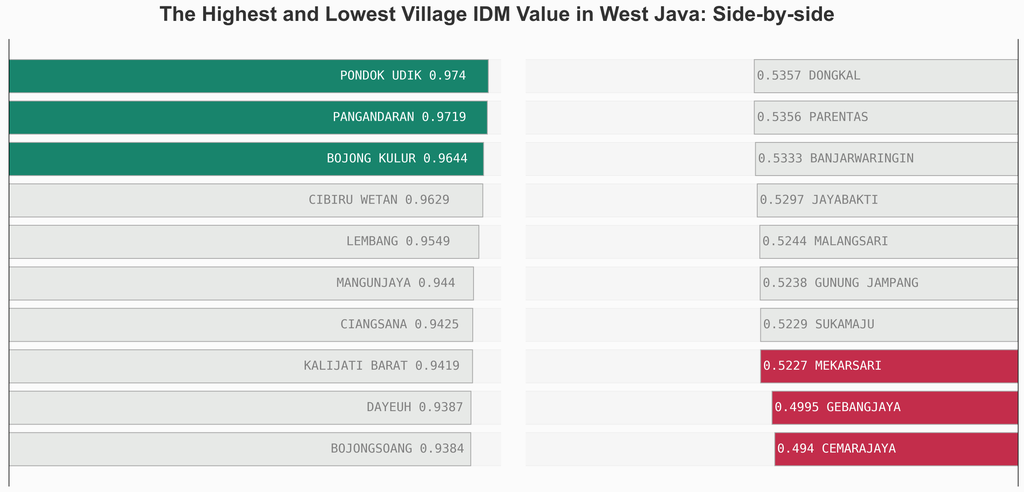

```python
top = df[['nama_provinsi', 'bps_nama_kabupaten_kota', 'bps_nama_kecamatan', 'bps_nama_desa_kelurahan', 'nilai_idm_2020']].sort_values(by=['nilai_idm_2020'], ascending=False).reset_index(drop=True)[:10]
bottom = df[['nama_provinsi', 'bps_nama_kabupaten_kota', 'bps_nama_kecamatan', 'bps_nama_desa_kelurahan', 'nilai_idm_2020']].sort_values(by=['nilai_idm_2020'], ascending=True).reset_index(drop=True)[:10]

fig = plt.figure(figsize=(22,10),dpi=300)
gs = fig.add_gridspec(1, 2)
gs.update(wspace=0.05, hspace=0.27)
ax0 = fig.add_subplot(gs[0, 0])
ax1 = fig.add_subplot(gs[0, 1])


fig.patch.set_facecolor(background_color) # figure background color
ax0.set_facecolor(background_color)
ax1.set_facecolor(background_color)

color_map = ['#e7e9e7' for _ in range(10)]
color_map[0] = color_map[1] = color_map[2] =  color2 # color highlight

#base
ax0.barh(top['bps_nama_desa_kelurahan'][::-1], 10,
       edgecolor='darkgray',color='lightgray',alpha=0.1)
# actual
ax0.barh(top['bps_nama_desa_kelurahan'], top['nilai_idm_2020'],
       edgecolor='darkgray',color=color_map)

for i in range(7,10):
    ax0.annotate(list(top['bps_nama_desa_kelurahan'])[::-1][i] + ' ' + str(list(top['nilai_idm_2020'])[::-1][i]),
                   xy=(top['nilai_idm_2020'][::-1][i]-(top['nilai_idm_2020'][::-1][i]*0.01), i),
                   va = 'center', ha='right',fontweight='light', fontfamily='monospace',fontsize=15, color='white',rotation=0)
# diff color text
for i in range(0,7):
    ax0.annotate(list(top['bps_nama_desa_kelurahan'])[::-1][i] + ' ' + str(list(top['nilai_idm_2020'])[::-1][i]),
                   xy=(top['nilai_idm_2020'][::-1][i]-(top['nilai_idm_2020'][::-1][i]*0.05), i),
                   va = 'center', ha='right',fontweight='light', fontfamily='monospace',fontsize=15, color='gray',rotation=0)

color_map = ['#e7e9e7' for _ in range(10)]
color_map[0] = color_map[1] = color_map[2] =  color1 # color highlight

#base
ax1.barh(bottom['bps_nama_desa_kelurahan'], 10,
       edgecolor='darkgray',color='lightgray',alpha=0.1)
# actual
ax1.barh(bottom['bps_nama_desa_kelurahan'], bottom['nilai_idm_2020'],
       edgecolor='darkgray',color=color_map)

for i in range(0,10):
    ax1.annotate(str(list(bottom['nilai_idm_2020'])[i]) + ' ' + list(bottom['bps_nama_desa_kelurahan'])[i],
                 xy=(bottom['nilai_idm_2020'][i]-(bottom['nilai_idm_2020'][i]*0.01), i),
                 va = 'center', ha='left',fontweight='light', fontfamily='monospace',fontsize=15, color='gray',rotation=0)
# diff color text
for i in range(0,3):
    ax1.annotate(str(list(bottom['nilai_idm_2020'])[i]) + ' ' + list(bottom['bps_nama_desa_kelurahan'])[i],
                   xy=(bottom['nilai_idm_2020'][i]-(bottom['nilai_idm_2020'][i]*0.01), i),
                   va = 'center', ha='left',fontweight='light', fontfamily='monospace',fontsize=15, color='white',rotation=0)

for s in ['top', 'bottom', 'right']:
    ax0.spines[s].set_visible(False)

for s in ['top', 'bottom','left']:
    ax1.spines[s].set_visible(False)




ax0.set_xlim(0,1)
ax1.set_xlim(1,0)

# ax labels off

ax0.axes.get_xaxis().set_ticks([])
ax0.axes.get_yaxis().set_ticks([])
ax1.axes.get_xaxis().set_ticks([])
ax1.axes.get_yaxis().set_ticks([])

plt.figtext(0.5, 0.92, 'The Highest and Lowest Village IDM Value in West Java: Side-by-side',
            ha='center', va='center', fontsize=25, fontweight='bold', fontfamily='sans-serif',color='#323232')

plt.show()
```

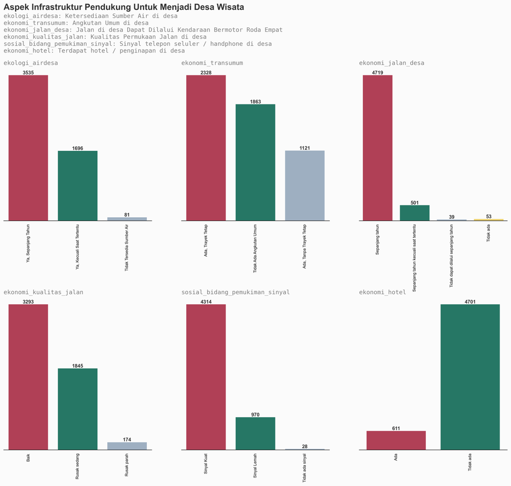

```python
infra_list = ['ekologi_airdesa', 'ekonomi_transumum', 'ekonomi_jalan_desa', 'ekonomi_kualitas_jalan',
              'sosial_bidang_pemukiman_sinyal', 'ekonomi_hotel']

fig = plt.figure(figsize=(18, 14), dpi=300,facecolor=background_color)
gs = fig.add_gridspec(2, 3)
gs.update(wspace=0.2, hspace=0.5)


plot = 0
for row in range(0, 2):
    for col in range(0, 3):
        locals()["ax"+str(plot)] = fig.add_subplot(gs[row, col])
        locals()["ax"+str(plot)].set_facecolor(background_color)
        locals()["ax"+str(plot)].get_yaxis().set_visible(False)
        locals()["ax"+str(plot)].tick_params(axis='both', which='both',left=False, bottom=False,labelbottom=True, labelsize=8, rotation=90)

        for s in ["top","right", "left"]:
            locals()["ax"+str(plot)].spines[s].set_visible(False)
        plot += 1

plot = 0

for md in infra_list:
    sns.countplot(data=df, x=md, palette=[color1, color2, '#98AFC7', '#FFDB58'], ax=locals()["ax"+str(plot)])
    locals()["ax"+str(plot)].set_title(md, fontfamily='monospace', color='gray', loc='left')
    locals()["ax"+str(plot)].set_xlabel('')
    for container in locals()["ax"+str(plot)].containers:
        locals()["ax"+str(plot)].bar_label(container, fontsize=10, fontweight='bold', fontfamily='sans-serif', color='#323232')

    plot += 1


Xstart, Xend = ax0.get_xlim()
Ystart, Yend = ax0.get_ylim()

ax0.text(Xstart, Yend+(Yend*0.38), 'Aspek Infrastruktur Pendukung Untuk Menjadi Desa Wisata', fontsize=17, fontweight='bold', fontfamily='sans-serif',color='#323232')
ax0.text(Xstart, Yend+(Yend*0.1), 'ekologi_airdesa: Ketersediaan Sumber Air di desa \nekonomi_transumum: Angkutan Umum di desa \nekonomi_jalan_desa: Jalan di desa Dapat Dilalui Kendaraan Bermotor Roda Empat \nekonomi_kualitas_jalan: Kualitas Permukaan Jalan di desa \nsosial_bidang_pemukiman_sinyal: Sinyal telepon seluler / handphone di desa \nekonomi_hotel: Terdapat hotel / penginapan di desa', fontsize=12, fontweight='light', fontfamily='monospace',color='gray')

plt.show()
```

```python
infrastruktur = df.groupby(['ekologi_airdesa', 'ekonomi_transumum', 'ekonomi_jalan_desa', 'ekonomi_kualitas_jalan',
                     'sosial_bidang_pemukiman_sinyal', 'ekonomi_hotel'])['bps_nama_desa_kelurahan'].count().reset_index()
infrastruktur.iloc[154:160]
```

|  | ekologi_airdesa | ekonomi_transumum | ekonomi_jalan_desa | ekonomi_kualitas_jalan | sosial_bidang_pemukiman_sinyal | ekonomi_hotel | bps_nama_desa_kelurahan |
| --- | --- | --- | --- | --- | --- | --- | --- |
| 154 | Ya, Sepanjang Tahun | Ada, Trayek Tetap | Sepanjang tahun | Baik | Sinyal Kuat | Ada | 183 |
| 155 | Ya, Sepanjang Tahun | Ada, Trayek Tetap | Sepanjang tahun | Baik | Sinyal Kuat | Tidak ada | 933 |
| 156 | Ya, Sepanjang Tahun | Ada, Trayek Tetap | Sepanjang tahun | Baik | Sinyal Lemah | Ada | 8 |
| 157 | Ya, Sepanjang Tahun | Ada, Trayek Tetap | Sepanjang tahun | Baik | Sinyal Lemah | Tidak ada | 61 |
| 158 | Ya, Sepanjang Tahun | Ada, Trayek Tetap | Sepanjang tahun | Baik | Tidak ada sinyal | Tidak ada | 2 |
| 159 | Ya, Sepanjang Tahun | Ada, Trayek Tetap | Sepanjang tahun | Rusak parah | Sinyal Kuat | Ada | 1 |

```python
infrastruktur_1 = df[(df.ekologi_airdesa=='Ya, Sepanjang Tahun') & (df.ekonomi_transumum=='Ada, Trayek Tetap') & (df.ekonomi_jalan_desa=='Sepanjang tahun')
              & (df.ekonomi_kualitas_jalan=='Baik') & (df.sosial_bidang_pemukiman_sinyal=='Sinyal Kuat') & (df.ekonomi_hotel=='Ada')]
infrastruktur_1.head()
```

|  | nama_provinsi | bps_nama_kabupaten_kota | bps_nama_kecamatan | bps_nama_desa_kelurahan | iks_2020 | ike_2020 | ikl_2020 | nilai_idm_2020 | status_idm_2020 | ekologi_airdesa | ekologi_dampak_cemar | ekonomi_transumum | ekonomi_jalan_desa | ekonomi_kualitas_jalan | ekonomi_status_bumdesa | ekonomi_status_bumdesa_bersama | ekonomi_bumdes_bid_pariwisata | sosial_bidang_modal_sosial_suku | sosial_bidang_modal_sosial_bahasa | sosial_bidang_modal_sosial_agama_mayoritas | sosial_bidang_pemukiman_sinyal | ekonomi_hotel | ekonomi_jarak_hotel | ekonomi_menit_hotel | ekonomi_penghasilan | ekonomi_produk_unggul | ekonomi_umikrokecil_industri_rt | ekonomi_umikrokecil_pariwisata | ekonomi_umikrokecil_perikanan | … |
| --- | --- | --- | --- | --- | --- | --- | --- | --- | --- | --- | --- | --- | --- | --- | --- | --- | --- | --- | --- | --- | --- | --- | --- | --- | --- | --- | --- | --- | --- | --- |
| 0 | JAWA BARAT | KABUPATEN BOGOR | GUNUNG PUTRI | WANAHERANG | 0.9486 | 0.8500 | 0.3333 | 0.7106 | MAJU | Ya, Sepanjang Tahun | Gangguan Kesehatan Ringan | Ada, Trayek Tetap | Sepanjang tahun | Baik | Aktif | Tidak aktif | Tidak ada | 5 | 5 | Ada | Sinyal Kuat | Ada | 1000 | 10 | Industri | Tidak ada | 0 | 0 | 0 | … |
| 1 | JAWA BARAT | KABUPATEN BOGOR | GUNUNG PUTRI | BOJONG KULUR | 0.9600 | 1.0000 | 0.9333 | 0.9644 | MANDIRI | Ya, Sepanjang Tahun | Gangguan Kesehatan Ringan | Ada, Trayek Tetap | Sepanjang tahun | Baik | Aktif | Tidak aktif | Tidak ada | 2 | 3 | Ada | Sinyal Kuat | Ada | 300 | 3 | Perdagangan, Trans, dan Jasa | Tidak ada | 8 | 0 | 0 | … |
| 24 | JAWA BARAT | KABUPATEN BOGOR | SUKARAJA | CILEBUT BARAT | 0.8457 | 0.8167 | 0.5333 | 0.7319 | MAJU | Ya, Sepanjang Tahun | Gangguan Kesehatan Ringan | Ada, Trayek Tetap | Sepanjang tahun | Baik | Tidak aktif | Tidak aktif | Tidak ada | 2 | 2 | Ada | Sinyal Kuat | Ada | 0 | 0 | Perdagangan, Trans, dan Jasa | Ada | 5 | 0 | 0 | … |
| 26 | JAWA BARAT | KABUPATEN BOGOR | SUKARAJA | NAGRAK | 0.8057 | 0.6167 | 0.6000 | 0.6741 | BERKEMBANG | Ya, Sepanjang Tahun | Gangguan Kesehatan Ringan | Ada, Trayek Tetap | Sepanjang tahun | Baik | Tidak aktif | Tidak aktif | Tidak ada | 6 | 2 | Ada | Sinyal Kuat | Ada | 2000 | 35 | Lainnya | Ada | 2 | 0 | 0 | … |
| 37 | JAWA BARAT | KABUPATEN BOGOR | BABAKAN MADANG | SENTUL | 0.8971 | 0.8333 | 0.5333 | 0.7546 | MAJU | Ya, Sepanjang Tahun | Tidak Mempengaruhi Kesehatan | Ada, Trayek Tetap | Sepanjang tahun | Baik | Aktif | Tidak aktif | Tidak ada | 0 | 2 | Ada | Sinyal Kuat | Ada | 200 | 10 | Industri | Ada | 9 | 1 | 0 | … |

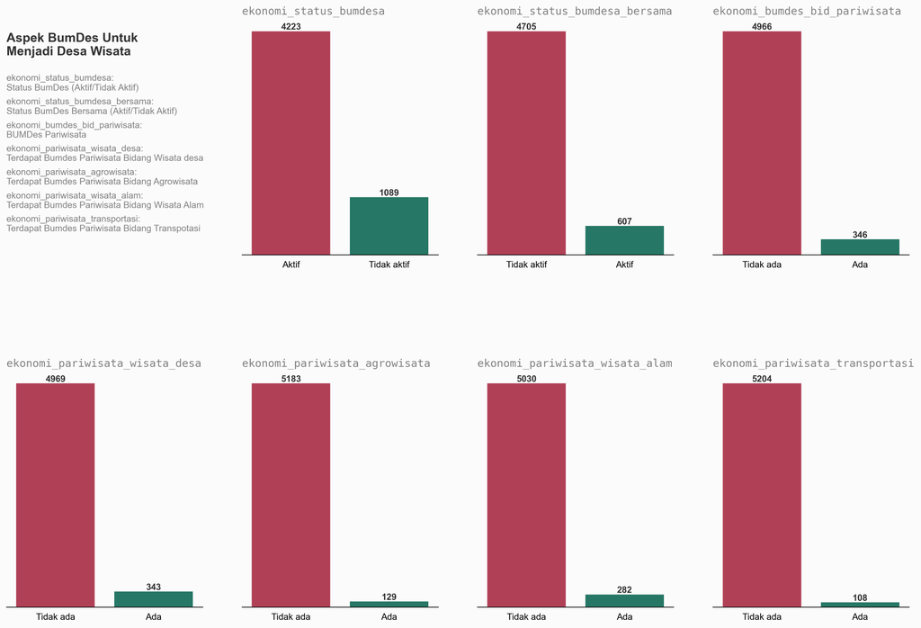

```python
bumDes_list = ['ekonomi_status_bumdesa', 'ekonomi_status_bumdesa_bersama', 'ekonomi_bumdes_bid_pariwisata',
             'ekonomi_pariwisata_wisata_desa','ekonomi_pariwisata_agrowisata', 'ekonomi_pariwisata_wisata_alam',
             'ekonomi_pariwisata_transportasi']

fig = plt.figure(figsize=(18, 12), dpi=300,facecolor=background_color)
gs = fig.add_gridspec(2, 4)
gs.update(wspace=0.2, hspace=0.5)


plot = 0
for row in range(0, 2):
    for col in range(0, 4):
        locals()["ax"+str(plot)] = fig.add_subplot(gs[row, col])
        locals()["ax"+str(plot)].set_facecolor(background_color)
        locals()["ax"+str(plot)].get_yaxis().set_visible(False)
        locals()["ax"+str(plot)].tick_params(axis='both', which='both',left=False, bottom=False,labelbottom=True, labelsize=10)

        for s in ["top","right", "left"]:
            locals()["ax"+str(plot)].spines[s].set_visible(False)
        plot += 1

plot = 1

for md in bumDes_list:
    sns.countplot(data=df, x=md, palette=[color1, color2, '#98AFC7', '#FFDB58'], ax=locals()["ax"+str(plot)])
    locals()["ax"+str(plot)].set_title(md, fontfamily='monospace', color='gray', loc='left')
    locals()["ax"+str(plot)].set_xlabel('')
    for container in locals()["ax"+str(plot)].containers:
        locals()["ax"+str(plot)].bar_label(container, fontsize=10, fontweight='bold', fontfamily='sans-serif', color='#323232')

    plot += 1


for s in ['top','right','left','bottom']:
    ax0.spines[s].set_visible(False)
ax0.text(0,0.85,"Aspek BumDes Untuk \nMenjadi Desa Wisata",color='#323232',fontsize=14, fontweight='bold', fontfamily='sans-serif',ha='left')
ax0.text(0,0.7,"ekonomi_status_bumdesa: \nStatus BumDes (Aktif/Tidak Aktif)",color='gray',fontsize=10, fontfamily='sans-serif',ha='left')
ax0.text(0,0.6,"ekonomi_status_bumdesa_bersama: \nStatus BumDes Bersama (Aktif/Tidak Aktif)",color='gray',fontsize=10, fontfamily='sans-serif',ha='left')
ax0.text(0,0.5,"ekonomi_bumdes_bid_pariwisata: \nBUMDes Pariwisata",color='gray',fontsize=10, fontfamily='sans-serif',ha='left')
ax0.text(0,0.4,"ekonomi_pariwisata_wisata_desa: \nTerdapat Bumdes Pariwisata Bidang Wisata desa",color='gray',fontsize=10, fontfamily='sans-serif',ha='left')
ax0.text(0,0.3,"ekonomi_pariwisata_agrowisata: \nTerdapat Bumdes Pariwisata Bidang Agrowisata",color='gray',fontsize=10, fontfamily='sans-serif',ha='left')
ax0.text(0,0.2,"ekonomi_pariwisata_wisata_alam: \nTerdapat Bumdes Pariwisata Bidang Wisata Alam",color='gray',fontsize=10, fontfamily='sans-serif',ha='left')
ax0.text(0,0.1,"ekonomi_pariwisata_transportasi: \nTerdapat Bumdes Pariwisata Bidang Transpotasi",color='gray',fontsize=10, fontfamily='sans-serif',ha='left')

ax0.set_yticklabels('')
ax0.set_xticklabels('')
ax0.tick_params(axis='both',length=0)

plt.show()
```

```python
bumdes = df.groupby(['ekonomi_status_bumdesa','ekonomi_bumdes_bid_pariwisata','ekonomi_pariwisata_wisata_desa','ekonomi_pariwisata_agrowisata', 'ekonomi_pariwisata_wisata_alam',
             'ekonomi_pariwisata_transportasi'])['bps_nama_desa_kelurahan'].count().reset_index()
bumdes.head()
```

|  | ekonomi_status_bumdesa | ekonomi_bumdes_bid_pariwisata | ekonomi_pariwisata_wisata_desa | ekonomi_pariwisata_agrowisata | ekonomi_pariwisata_wisata_alam | ekonomi_pariwisata_transportasi | bps_nama_desa_kelurahan |
| --- | --- | --- | --- | --- | --- | --- | --- |
| 0 | Aktif | Ada | Ada | Ada | Ada | Ada | 24 |
| 1 | Aktif | Ada | Ada | Ada | Ada | Tidak ada | 47 |
| 2 | Aktif | Ada | Ada | Ada | Tidak ada | Tidak ada | 4 |
| 3 | Aktif | Ada | Ada | Tidak ada | Ada | Ada | 11 |
| 4 | Aktif | Ada | Ada | Tidak ada | Ada | Tidak ada | 101 |

```python
bumdes_1 = df[(df.ekonomi_status_bumdesa=='Aktif') & (df.ekonomi_bumdes_bid_pariwisata=='Ada') & (df.ekonomi_pariwisata_wisata_desa=='Ada')
              & (df.ekonomi_pariwisata_agrowisata=='Ada') & (df.ekonomi_pariwisata_wisata_alam=='Ada') & (df.ekonomi_pariwisata_transportasi=='Ada')]
bumdes_1.head()
```

|  | nama_provinsi | bps_nama_kabupaten_kota | bps_nama_kecamatan | bps_nama_desa_kelurahan | iks_2020 | ike_2020 | ikl_2020 | nilai_idm_2020 | status_idm_2020 | ekologi_airdesa | ekologi_dampak_cemar | ekonomi_transumum | ekonomi_jalan_desa | ekonomi_kualitas_jalan | ekonomi_status_bumdesa | ekonomi_status_bumdesa_bersama | ekonomi_bumdes_bid_pariwisata | sosial_bidang_modal_sosial_suku | sosial_bidang_modal_sosial_bahasa | sosial_bidang_modal_sosial_agama_mayoritas | sosial_bidang_pemukiman_sinyal | ekonomi_hotel | ekonomi_jarak_hotel | ekonomi_menit_hotel | ekonomi_penghasilan | ekonomi_produk_unggul | ekonomi_umikrokecil_industri_rt | ekonomi_umikrokecil_pariwisata | ekonomi_umikrokecil_perikanan | … |
| --- | --- | --- | --- | --- | --- | --- | --- | --- | --- | --- | --- | --- | --- | --- | --- | --- | --- | --- | --- | --- | --- | --- | --- | --- | --- | --- | --- | --- | --- | --- |
| 147 | JAWA BARAT | KABUPATEN BOGOR | CIAMPEA | BENTENG | 0.9143 | 0.8333 | 0.7333 | 0.8270 | MANDIRI | Ya, Kecuali Saat Tertentu | Gangguan Kesehatan Ringan | Ada, Trayek Tetap | Sepanjang tahun | Rusak sedang | Aktif | Tidak aktif | Ada | 9 | 5 | Ada | Sinyal Kuat | Tidak ada | 2000 | 30 | Perdagangan, Trans, dan Jasa | Ada | 50 | 1 | 0 | … |
| 156 | JAWA BARAT | KABUPATEN BOGOR | CIBUNGBULANG | CIMANGGU II | 0.8171 | 0.7667 | 0.8000 | 0.7946 | MAJU | Ya, Sepanjang Tahun | Gangguan Kesehatan Ringan | Ada, Tanpa Trayek Tetap | Sepanjang tahun | Baik | Aktif | Aktif | Ada | 5 | 2 | Ada | Sinyal Kuat | Tidak ada | 0 | 0 | Perdagangan, Trans, dan Jasa | Ada | 7 | 1 | 2 | … |
| 268 | JAWA BARAT | KABUPATEN BOGOR | CISARUA | BATULAYANG | 0.8629 | 0.6667 | 0.8000 | 0.7765 | MAJU | Ya, Sepanjang Tahun | Tidak Mempengaruhi Kesehatan | Tidak Ada Angkutan Umum | Sepanjang tahun | Baik | Aktif | Tidak aktif | Ada | 8 | 2 | Ada | Sinyal Kuat | Ada | 100 | 50 | Perdagangan, Trans, dan Jasa | Ada | 20 | 100 | 10 | … |
| 269 | JAWA BARAT | KABUPATEN BOGOR | CISARUA | JOGJOGAN | 0.8286 | 0.5333 | 0.5333 | 0.6317 | BERKEMBANG | Ya, Sepanjang Tahun | Gangguan Kesehatan Ringan | Tidak Ada Angkutan Umum | Sepanjang tahun | Baik | Aktif | Tidak aktif | Ada | 10 | 2 | Ada | Sinyal Kuat | Ada | 500 | 10 | Perdagangan, Trans, dan Jasa | Ada | 11 | 20 | 0 | … |
| 276 | JAWA BARAT | KABUPATEN BOGOR | CISARUA | TUGU UTARA | 0.8800 | 0.7167 | 0.9333 | 0.8433 | MANDIRI | Ya, Sepanjang Tahun | Tidak Mempengaruhi Kesehatan | Tidak Ada Angkutan Umum | Sepanjang tahun | Baik | Aktif | Tidak aktif | Ada | 10 | 2 | Ada | Sinyal Kuat | Ada | 100 | 50 | Perdagangan, Trans, dan Jasa | Ada | 180 | 120 | 10 | … |

## Kondisi ideal

### Kondisi ideal yang dimaksud disini adalah desa dengan aspek infrastruktur dan BumDes terpenuhi semuanya

```python
ideal = infrastruktur_1[(infrastruktur_1.ekonomi_status_bumdesa=='Aktif') & (infrastruktur_1.ekonomi_bumdes_bid_pariwisata=='Ada')
                        & (infrastruktur_1.ekonomi_pariwisata_wisata_desa=='Ada')& (infrastruktur_1.ekonomi_pariwisata_agrowisata=='Ada')
                        & (infrastruktur_1.ekonomi_pariwisata_wisata_alam=='Ada') & (infrastruktur_1.ekonomi_pariwisata_transportasi=='Ada')]
ideal
```

|  | nama_provinsi | bps_nama_kabupaten_kota | bps_nama_kecamatan | bps_nama_desa_kelurahan | iks_2020 | ike_2020 | ikl_2020 | nilai_idm_2020 | status_idm_2020 | ekologi_airdesa | ekologi_dampak_cemar | ekonomi_transumum | ekonomi_jalan_desa | ekonomi_kualitas_jalan | ekonomi_status_bumdesa | ekonomi_status_bumdesa_bersama | ekonomi_bumdes_bid_pariwisata | sosial_bidang_modal_sosial_suku | sosial_bidang_modal_sosial_bahasa | sosial_bidang_modal_sosial_agama_mayoritas | sosial_bidang_pemukiman_sinyal | ekonomi_hotel | ekonomi_jarak_hotel | ekonomi_menit_hotel | ekonomi_penghasilan | ekonomi_produk_unggul | ekonomi_umikrokecil_industri_rt | ekonomi_umikrokecil_pariwisata | ekonomi_umikrokecil_perikanan | … |
| --- | --- | --- | --- | --- | --- | --- | --- | --- | --- | --- | --- | --- | --- | --- | --- | --- | --- | --- | --- | --- | --- | --- | --- | --- | --- | --- | --- | --- | --- | --- |
| 5057 | JAWA BARAT | KABUPATEN BANDUNG BARAT | PARONGPONG | CIHIDEUNG | 0.9314 | 0.9333 | 0.7333 | 0.8660 | MANDIRI | Ya, Sepanjang Tahun | Gangguan Kesehatan Ringan | Ada, Trayek Tetap | Sepanjang tahun | Baik | Aktif | Tidak aktif | Ada | 2 | 2 | Ada | Sinyal Kuat | Ada | 5040 | 15 | Pertanian | Ada | 23 | 39 | 44 | … |
| 5058 | JAWA BARAT | KABUPATEN BANDUNG BARAT | PARONGPONG | CIWARUGA | 0.9029 | 0.8000 | 0.6000 | 0.7676 | MAJU | Ya, Sepanjang Tahun | Gangguan Kesehatan Ringan | Ada, Trayek Tetap | Sepanjang tahun | Baik | Aktif | Tidak aktif | Ada | 2 | 2 | Ada | Sinyal Kuat | Ada | 1000 | 10 | Perdagangan, Trans, dan Jasa | Ada | 47 | 32 | 11 | … |

- Status idm kedua desa tersebut dalah MANDIRI dan MAJU
- Kedua desa tersebut berada di kabupaten dan kecamatan yang sama
- Kedua desa tersebut memiliki dampak pencemaran lingkungan yaitu Gangguan Kesehatan Ringan
- Kedua desa tersebut status bumdes bersamanya tidak aktif
- Sumber penghasilan utama penduduk desanya adalah pertanian dan Perdagangan, Trans, dan Jasa

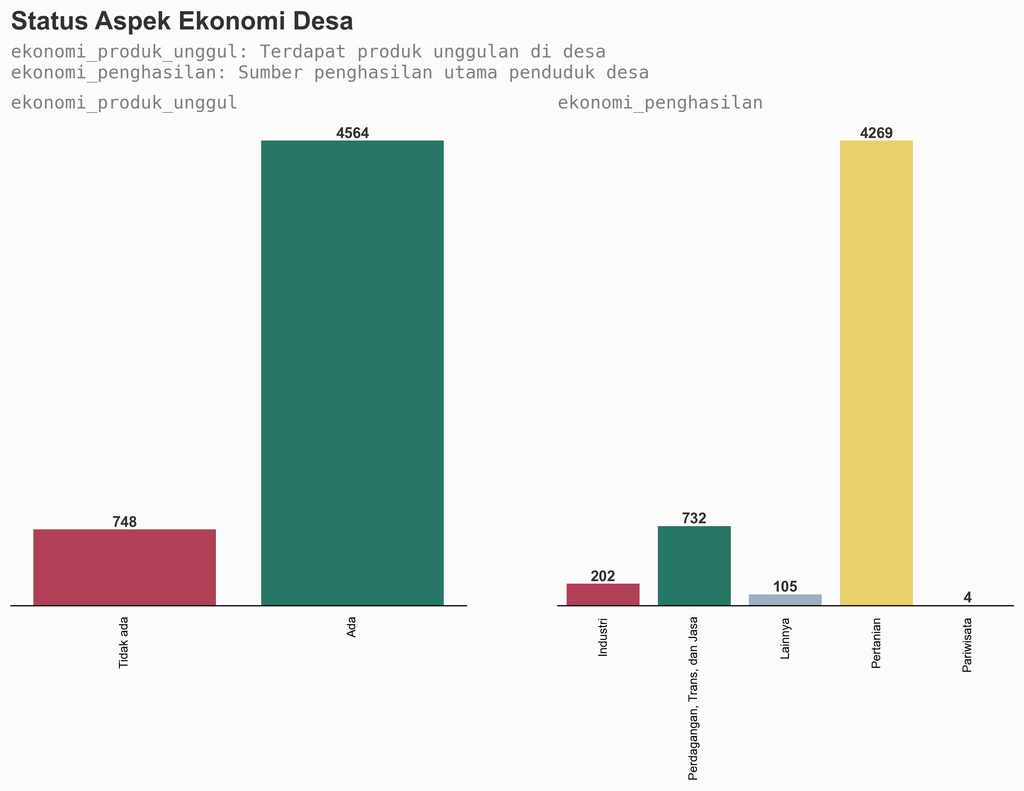

```python
infra_list = ['ekonomi_produk_unggul', 'ekonomi_penghasilan']

fig = plt.figure(figsize=(12, 6), dpi=300,facecolor=background_color)
gs = fig.add_gridspec(1, 2)
gs.update(wspace=0.2, hspace=0.5)


plot = 0
for row in range(0, 1):
    for col in range(0, 2):
        locals()["ax"+str(plot)] = fig.add_subplot(gs[row, col])
        locals()["ax"+str(plot)].set_facecolor(background_color)
        locals()["ax"+str(plot)].get_yaxis().set_visible(False)
        locals()["ax"+str(plot)].tick_params(axis='both', which='both',left=False, bottom=False,labelbottom=True, labelsize=8, rotation=90)

        for s in ["top","right", "left"]:
            locals()["ax"+str(plot)].spines[s].set_visible(False)
        plot += 1

plot = 0

for md in infra_list:
    sns.countplot(data=df, x=md, palette=[color1, color2, '#98AFC7', '#FFDB58'], ax=locals()["ax"+str(plot)])
    locals()["ax"+str(plot)].set_title(md, fontfamily='monospace', color='gray', loc='left')
    locals()["ax"+str(plot)].set_xlabel('')
    for container in locals()["ax"+str(plot)].containers:
        locals()["ax"+str(plot)].bar_label(container, fontsize=10, fontweight='bold', fontfamily='sans-serif', color='#323232')

    plot += 1


Xstart, Xend = ax0.get_xlim()
Ystart, Yend = ax0.get_ylim()

ax0.text(Xstart, Yend+(Yend*0.18), 'Status Aspek Ekonomi Desa', fontsize=17, fontweight='bold', fontfamily='sans-serif',color='#323232')
ax0.text(Xstart, Yend+(Yend*0.08), 'ekonomi_produk_unggul: Terdapat produk unggulan di desa \nekonomi_penghasilan: Sumber penghasilan utama penduduk desa', fontsize=12, fontweight='light', fontfamily='monospace',color='gray')

plt.show()
```

- Sebagian besar desa memiliki produk unggulan
- Hanya 4 desa yang sumber penghasilan utamanya adalah pariwisata

```python
df_desaPariwisata = df[df.ekonomi_penghasilan == 'Pariwisata']
df_desaPariwisata.head()
```

|  | nama_provinsi | bps_nama_kabupaten_kota | bps_nama_kecamatan | bps_nama_desa_kelurahan | iks_2020 | ike_2020 | ikl_2020 | nilai_idm_2020 | status_idm_2020 | ekologi_airdesa | ekologi_dampak_cemar | ekonomi_transumum | ekonomi_jalan_desa | ekonomi_kualitas_jalan | ekonomi_status_bumdesa | ekonomi_status_bumdesa_bersama | ekonomi_bumdes_bid_pariwisata | sosial_bidang_modal_sosial_suku | sosial_bidang_modal_sosial_bahasa | sosial_bidang_modal_sosial_agama_mayoritas | sosial_bidang_pemukiman_sinyal | ekonomi_hotel | ekonomi_jarak_hotel | ekonomi_menit_hotel | ekonomi_penghasilan | ekonomi_produk_unggul | ekonomi_umikrokecil_industri_rt | ekonomi_umikrokecil_pariwisata | ekonomi_umikrokecil_perikanan | … |
| --- | --- | --- | --- | --- | --- | --- | --- | --- | --- | --- | --- | --- | --- | --- | --- | --- | --- | --- | --- | --- | --- | --- | --- | --- | --- | --- | --- | --- | --- | --- |
| 166 | JAWA BARAT | KABUPATEN BOGOR | PAMIJAHAN | CIBITUNGWETAN | 0.7714 | 0.6000 | 0.6000 | 0.6571 | BERKEMBANG | Ya, Kecuali Saat Tertentu | Gangguan Kesehatan Ringan | Tidak Ada Angkutan Umum | Sepanjang tahun | Baik | Aktif | Aktif | Ada | 1 | 2 | Ada | Sinyal Kuat | Ada | 0 | 0 | Pariwisata | Ada | 6 | 1 | 0 | … |
| 330 | JAWA BARAT | KABUPATEN BOGOR | TAMANSARI | SUKAMANTRI | 0.8857 | 0.6833 | 0.6667 | 0.7452 | MAJU | Ya, Sepanjang Tahun | Tidak Mempengaruhi Kesehatan | Ada, Trayek Tetap | Sepanjang tahun | Baik | Aktif | Tidak aktif | Tidak ada | 5 | 2 | Ada | Sinyal Kuat | Tidak ada | 0 | 0 | Pariwisata | Ada | 4 | 0 | 0 | … |
| 409 | JAWA BARAT | KABUPATEN BOGOR | TENJOLAYA | TAPOS I | 0.8000 | 0.6333 | 0.4667 | 0.6333 | BERKEMBANG | Ya, Kecuali Saat Tertentu | Gangguan Kesehatan Ringan | Ada, Tanpa Trayek Tetap | Sepanjang tahun | Rusak sedang | Aktif | Tidak aktif | Ada | 1 | 2 | Ada | Sinyal Kuat | Ada | 100 | 500 | Pariwisata | Ada | 3 | 3 | 5 | … |
| 1107 | JAWA BARAT | KABUPATEN CIANJUR | CIPANAS | CILOTO | 0.7829 | 0.6333 | 0.4000 | 0.6054 | BERKEMBANG | Ya, Sepanjang Tahun | Menimbulkan Penyakit | Ada, Tanpa Trayek Tetap | Sepanjang tahun | Baik | Tidak aktif | Tidak aktif | Tidak ada | 2 | 2 | Ada | Sinyal Kuat | Ada | 400 | 5 | Pariwisata | Ada | 0 | 0 | 0 | … |

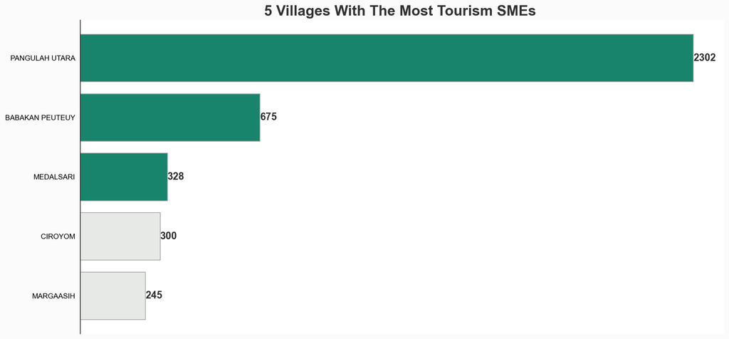

```python
top_umkmPariwisata = df.sort_values(by=['ekonomi_umikrokecil_pariwisata'], ascending=False).reset_index(drop=True)[:5]
fig, axes = plt.subplots(figsize=(16,8), dpi=150, facecolor=background_color)
gs = fig.add_gridspec(1, 2)
gs.update(wspace=0.05, hspace=0.27)
fig.patch.set_facecolor(background_color) # figure background color

color_map = ['#e7e9e7' for _ in range(5)]
color_map[-1] = color_map[-2] = color_map[-3] =  color2 # color highlight

axes.barh(top_umkmPariwisata['bps_nama_desa_kelurahan'][::-1], top_umkmPariwisata['ekonomi_umikrokecil_pariwisata'][::-1],
       edgecolor='darkgray',color=color_map)

axes.set_title('5 Villages With The Most Tourism SMEs ', fontsize=20, fontweight='bold', fontfamily='sans-serif',color='#323232')

axes.tick_params(axis='both', which='both',left=False, bottom=False,labelbottom=False)

for s in ["top","right", "bottom"]:
    axes.spines[s].set_visible(False)

for container in axes.containers:
    axes.bar_label(container, fontsize=14, fontweight='bold', fontfamily='sans-serif', color='#323232')

plt.show()
```

```python
top_umkmPariwisata
```

|  | nama_provinsi | bps_nama_kabupaten_kota | bps_nama_kecamatan | bps_nama_desa_kelurahan | iks_2020 | ike_2020 | ikl_2020 | nilai_idm_2020 | status_idm_2020 | ekologi_airdesa | ekologi_dampak_cemar | ekonomi_transumum | ekonomi_jalan_desa | ekonomi_kualitas_jalan | ekonomi_status_bumdesa | ekonomi_status_bumdesa_bersama | ekonomi_bumdes_bid_pariwisata | sosial_bidang_modal_sosial_suku | sosial_bidang_modal_sosial_bahasa | sosial_bidang_modal_sosial_agama_mayoritas | sosial_bidang_pemukiman_sinyal | ekonomi_hotel | ekonomi_jarak_hotel | ekonomi_menit_hotel | ekonomi_penghasilan | ekonomi_produk_unggul | ekonomi_umikrokecil_industri_rt | ekonomi_umikrokecil_pariwisata | ekonomi_umikrokecil_perikanan | … |
| --- | --- | --- | --- | --- | --- | --- | --- | --- | --- | --- | --- | --- | --- | --- | --- | --- | --- | --- | --- | --- | --- | --- | --- | --- | --- | --- | --- | --- | --- | --- |
| 0 | JAWA BARAT | KABUPATEN KARAWANG | KOTA BARU | PANGULAH UTARA | 0.9143 | 0.6833 | 0.6000 | 0.7325 | MAJU | Ya, Sepanjang Tahun | Gangguan Kesehatan Ringan | Ada, Tanpa Trayek Tetap | Sepanjang tahun | Baik | Aktif | Tidak aktif | Ada | 2 | 2 | Ada | Sinyal Kuat | Tidak ada | 0 | 0 | Lainnya | Ada | 454 | 2302 | 3 | … |
| 1 | JAWA BARAT | KABUPATEN BANDUNG | CICALENGKA | BABAKAN PEUTEUY | 0.9143 | 0.7167 | 0.4667 | 0.6992 | BERKEMBANG | Ya, Sepanjang Tahun | Gangguan Kesehatan Ringan | Tidak Ada Angkutan Umum | Sepanjang tahun | Rusak sedang | Aktif | Tidak aktif | Tidak ada | 3 | 2 | Ada | Sinyal Kuat | Tidak ada | 7500 | 200 | Perdagangan, Trans, dan Jasa | Ada | 637 | 675 | 4 | … |
| 2 | JAWA BARAT | KABUPATEN KARAWANG | PANGKALAN | MEDALSARI | 0.7600 | 0.5333 | 0.5333 | 0.6089 | BERKEMBANG | Ya, Kecuali Saat Tertentu | Tidak Mempengaruhi Kesehatan | Tidak Ada Angkutan Umum | Sepanjang tahun kecuali saat tertentu | Rusak sedang | Aktif | Tidak aktif | Ada | 2 | 2 | Ada | Sinyal Lemah | Tidak ada | 10000 | 39 | Pertanian | Ada | 320 | 328 | 0 | … |
| 3 | JAWA BARAT | KABUPATEN BANDUNG BARAT | CIPEUNDEUY | CIROYOM | 0.8743 | 0.7167 | 0.6000 | 0.7303 | MAJU | Ya, Kecuali Saat Tertentu | Tidak Mempengaruhi Kesehatan | Ada, Trayek Tetap | Sepanjang tahun | Rusak sedang | Aktif | Tidak aktif | Ada | 4 | 2 | Ada | Sinyal Kuat | Ada | 300 | 10 | Pertanian | Ada | 102 | 300 | 95 | … |
| 4 | JAWA BARAT | KABUPATEN BANDUNG | CICALENGKA | MARGAASIH | 0.7943 | 0.5667 | 0.7333 | 0.6981 | BERKEMBANG | Ya, Sepanjang Tahun | Gangguan Kesehatan Ringan | Tidak Ada Angkutan Umum | Sepanjang tahun | Rusak sedang | Aktif | Tidak aktif | Tidak ada | 2 | 2 | Ada | Sinyal Kuat | Tidak ada | 7600 | 20 | Pertanian | Ada | 437 | 245 | 1 | … |

- 1 dari 5 desa dengan jumlah industri mikro dan kecil komoditas pariwisata terbanyak memiliki kualitas jalan yang baik yaitu desa Pangulah Utara yang juga merupakan desa dengan jumlah industri mikro dan kecil komoditas pariwisata terbanyak pertama
- 2 dari 5 desa dengan jumlah industri mikro dan kecil komoditas pariwisata terbanyak tidak memiliki bumdes bid pariwisata
- 1 dari 5 dengan jumlah industri mikro dan kecil komoditas pariwisata terbanyak memiliki sinyal yang lemah yaitu desa medalsari
- Hanya 1 dari 5 desa dengan jumlah industri mikro dan kecil komoditas pariwisata terbanyak yang memiliki hotel yaitu desa CIROYOM
- Desa dengan jumlah industri mikro dan kecil komoditas pariwisata terbanyak tidak memiliki hotel yaitu desa Pangulah Utara
- 3 dari 5 desa dengan jumlah industri mikro dan kecil komoditas pariwisata terbanyak ekonomi penghasilan utamanya adalah pertanian
- 2 dari 5 desa dengan jumlah industri mikro dan kecil komoditas pariwisata terbanyak tidak memiliki bumdes pariwisata bidang wisata desa
- 5 desa dengan jumlah industri mikro dan kecil komoditas pariwisata terbanyak tidak memiliki bumdes pariwisata bidang agrowisata
- 3 dari 5 desa dengan jumlah industri mikro dan kecil komoditas pariwisata terbanyak tidak memiliki bumdes pariwisata bidang wisata alam
- 5 desa dengan jumlah industri mikro dan kecil komoditas pariwisata terbanyak tidak memiliki bumdes pariwisata bidang transportasi